# Feedback Viewing

Sydney Wood

## Libraries and Packages

```r
# Package names
packages <- c("ggplot2",  "tidyverse", "apaTables", "colourpicker", "swirl", "dplyr", "gridExtra", "knitr", "lme4", "reshape2", "stargazer",  "did", "plm", "sandwich", "coefplot", "afex", "jtools", "glmmTMB")



# Install packages not yet installed
installed_packages <- packages %in% rownames(installed.packages())
if (any(installed_packages == FALSE)) {
  install.packages(packages[!installed_packages])
}

# Packages loading
invisible(lapply(packages, library, character.only = TRUE))
```

[output not shown]

# Data cleaning

## exam files

done for each observation changing file names to correspond with file — not the most efficient

```
Time 1 = Exam 1 feedback views & Exam 1 written score
Time 2 = Exam 2 feedback views & Exam 2 written score
Time 3 = Exam 3 feedback views & Exam 3 written score
Time 4 = Exam 4 feedback views & Exam 4 written score
No time 5 since they don't recieve feedback before the end of the quarter
```

time1data <- read.csv(file = “1_A_Feb15.csv”)

time1data <- time1data %>% mutate(writtenScore = rowSums(across(14:31)))

time1data <- time1data %>% mutate(pwritten = writtenScore/120) time1data <- time1data %>% filter(!is.na(View.Count))

time1data <- time1data %>% select(“SID”, “Total.Score”, “View.Count”, “pwritten”) time1data <- time1data %>% mutate(time = 2)

write.csv(time1data, file = “time2D.csv”, row.names = FALSE)

## combining exams

data2A <- read.csv(file = “time2A.csv”)

data2B <- read.csv(file = “time2B.csv”)

data2C <- read.csv(file = “time2C.csv”)

data2D <- read.csv(file = “time2D.csv”)

data2 <- rbind(data2A, data2B, data2C, data2D)

write.csv(data2, file = “FeedbackTime2.csv”, row.names = FALSE)

## combining observations

data1 <- read.csv(“FeedbackTime1.csv”) data2 <- read.csv(“FeedbackTime2.csv”) data3 <- read.csv(“FeedbackTime3.csv”) data4 <- read.csv(“FeedbackTime4.csv”)

data <- rbind(data1, data2, data3, data4)

write.csv(data, file = “FeedbackFull.csv”, row.names = FALSE)

# Descriptives

## full data

```r
setwd("~/GitHub/MC_data_cleaning/2023 data/new version of exams")

desc <- read.csv(file = "2023_cleaned.csv")
```

```r
data <- read.csv("FeedbackFull.csv")

data$time <- as.factor(data$time)

data <- data %>% mutate(viewed = case_when(View.Count == 0 ~ 0, View.Count > 0 ~ 1, .default = View.Count))

data <- data %>% mutate(Total.Score= Total.Score/150 *100) %>% mutate(pwritten = pwritten*100) %>% filter(opt_in != "#N/A")

data$student_id <- as.factor(data$SID)
data$SID <- as.factor(data$SID)
data$opt_in <- as.factor(data$opt_in)
```

```r
fulldata <- read.csv("~/GitHub/MC_data_cleaning/2023 data/Final_Data.csv")

score_data <- fulldata %>% select(SID = Real_id, anon_id = student_id, opt_in, exam1:exam5, p_tot1:p_tot5)



score_data$SID <- as.factor(score_data$SID)
score_data$opt_in <- as.factor(score_data$opt_in)

data <- right_join(data, score_data, by = c("SID", "opt_in"))

data <- data %>% mutate(f_score = case_when(time == "1" ~ p_tot2, time == "2"~p_tot3, time == "3"~p_tot4, time == "4" ~ p_tot5))

data <- data %>% mutate(p_score = case_when(time == "1" ~ exam1, time == "2"~exam2, time == "3"~exam3, time == "4" ~ exam4))
```

# Descriptives

```r
desc_l <- gather(desc, "Exam", "score", p_tot1, p_tot2, p_tot3, p_tot4, p_tot5)



writtenTable <- desc_l %>% group_by(Exam) %>% summarise(variable = "Performance", n = n(),
                                                    mean = mean(score, na.rm=T),
                                                    sd = sd(score, na.rm = T),
                                                    median = median(score, na.rm = T),
                                                    MAD = mad(score, na.rm = T),
                                                    Q1 = quantile(score, probs = .25, na.rm = T),
                                                    Q3 = quantile(score, probs = .75, na.rm = T),
                                                    IQR = IQR(score, na.rm = T),
                                                    min = min(score, na.rm = T),
                                                    max = max(score, na.rm = T))

writtenTable
```

| Exam | variable | n | mean | sd | median | MAD | Q1 | Q3 | IQR | min | max |
| --- | --- | --- | --- | --- | --- | --- | --- | --- | --- | --- | --- |
| p_tot1 | Performance | 379 | 74.62228 | 16.80166 | 78.00000 | 16.30860 | 65.87500 | 88.00000 | 22.12500 | 18.00000 | 99.00000 |
| p_tot2 | Performance | 379 | 72.40190 | 19.00705 | 77.27273 | 18.19555 | 60.90909 | 87.27273 | 26.36364 | 11.81818 | 100.00000 |
| p_tot3 | Performance | 379 | 61.96623 | 19.80738 | 63.21429 | 23.82750 | 47.14286 | 78.57143 | 31.42857 | 0.00000 | 98.57143 |
| p_tot4 | Performance | 379 | 79.89837 | 18.64849 | 86.00000 | 14.82600 | 70.00000 | 94.50000 | 24.50000 | 0.00000 | 100.00000 |
| p_tot5 | Performance | 379 | 79.41029 | 14.94996 | 81.66667 | 14.82600 | 70.83333 | 90.83333 | 20.00000 | 17.50000 | 100.00000 |

```r
written_optin_Table <- desc_l %>% group_by(Exam) %>% group_by(opt_in, .add = TRUE) %>%  summarise(variable = "Written Score", n = n(),
                                                    mean = mean(score, na.rm=T),
                                                    sd = sd(score, na.rm = T),
                                                    median = median(score, na.rm = T),
                                                    MAD = mad(score, na.rm = T),
                                                    Q1 = quantile(score, probs = .25, na.rm = T),
                                                    Q3 = quantile(score, probs = .75, na.rm = T),
                                                    IQR = IQR(score, na.rm = T),
                                                    min = min(score, na.rm = T),
                                                    max = max(score, na.rm = T))
written_optin_Table
```

| Exam | opt_in | variable | n | mean | sd | median | MAD | Q1 | Q3 | IQR | min | max |
| --- | --- | --- | --- | --- | --- | --- | --- | --- | --- | --- | --- | --- |
| p_tot1 | 0 | Written Score | 187 | 75.27624 | 14.78451 | 77.00000 | 14.82600 | 67.00000 | 86.50000 | 19.50000 | 30.000000 | 98.00000 |
| p_tot1 | 1 | Written Score | 192 | 73.98930 | 18.56484 | 78.50000 | 17.04990 | 63.00000 | 88.25000 | 25.25000 | 18.000000 | 99.00000 |
| p_tot2 | 0 | Written Score | 187 | 72.50749 | 18.53516 | 77.27273 | 18.53250 | 59.20455 | 87.72727 | 28.52273 | 15.000000 | 98.18182 |
| p_tot2 | 1 | Written Score | 192 | 72.30129 | 19.49424 | 77.72727 | 18.19555 | 62.04545 | 87.04545 | 25.00000 | 11.818182 | 100.00000 |
| p_tot3 | 0 | Written Score | 187 | 60.70635 | 20.31153 | 60.00000 | 21.18000 | 46.42857 | 77.50000 | 31.07143 | 0.000000 | 98.57143 |
| p_tot3 | 1 | Written Score | 192 | 63.17249 | 19.28935 | 65.71429 | 22.23900 | 47.67857 | 78.57143 | 30.89286 | 9.285714 | 97.14286 |
| p_tot4 | 0 | Written Score | 187 | 78.10112 | 18.09301 | 80.25000 | 20.75640 | 65.12500 | 93.87500 | 28.75000 | 8.000000 | 100.00000 |
| p_tot4 | 1 | Written Score | 192 | 81.57330 | 19.04634 | 88.00000 | 13.34340 | 73.50000 | 95.75000 | 22.25000 | 0.000000 | 100.00000 |
| p_tot5 | 0 | Written Score | 187 | 76.94444 | 15.19592 | 80.00000 | 13.59050 | 67.50000 | 87.50000 | 20.00000 | 34.583333 | 100.00000 |
| p_tot5 | 1 | Written Score | 192 | 81.71958 | 14.37577 | 85.00000 | 13.59050 | 73.33333 | 93.33333 | 20.00000 | 17.500000 | 100.00000 |

```r
write.csv(written_optin_Table, file = "performance_intervention.csv")
write.csv(writtenTable, file = "performance_overall.csv")



feedbackTable <- data %>% group_by(time) %>% summarise(variable = "Feedback Viewing", n = n(),
                                                    mean = mean(viewed, na.rm=T),
                                                    sd = sd(viewed, na.rm = T))

feedbackTable
```

| time | variable | n | mean | sd |
| --- | --- | --- | --- | --- |
| 1 | Feedback Viewing | 362 | 0.7348066 | 0.4420471 |
| 2 | Feedback Viewing | 367 | 0.6430518 | 0.4797534 |
| 3 | Feedback Viewing | 362 | 0.7983425 | 0.4017931 |
| 4 | Feedback Viewing | 365 | 0.6383562 | 0.4811359 |

```r
feedback_optin_Table <- data %>% group_by(time)  %>% group_by(opt_in, .add = TRUE) %>% summarise(variable = "Feedback Viewing", n = n(),
                                                    mean = mean(viewed, na.rm=T),
                                                    sd = sd(viewed, na.rm = T))
feedback_optin_Table
```

| time | opt_in | variable | n | mean | sd |
| --- | --- | --- | --- | --- | --- |
| 1 | 0 | Feedback Viewing | 176 | 0.6704545 | 0.4713892 |
| 1 | 1 | Feedback Viewing | 186 | 0.7956989 | 0.4042782 |
| 2 | 0 | Feedback Viewing | 177 | 0.5649718 | 0.4971671 |
| 2 | 1 | Feedback Viewing | 190 | 0.7157895 | 0.4522292 |
| 3 | 0 | Feedback Viewing | 175 | 0.6514286 | 0.4778853 |
| 3 | 1 | Feedback Viewing | 187 | 0.9358289 | 0.2457154 |
| 4 | 0 | Feedback Viewing | 175 | 0.5600000 | 0.4978113 |
| 4 | 1 | Feedback Viewing | 190 | 0.7105263 | 0.4547163 |

```r
feedback <- data %>% summarise(
  pViewed = mean(viewed, na.rm = T),
  sdViewed = sd(viewed, na.rm = T)
)

write.csv(feedback_optin_Table, file = "feedback_intervention.csv")
write.csv(feedbackTable, file = "feedback_overall.csv")
```

unit <- c(“Exam 1”, “Exam 2”, “Exam 3”, “Exam 4”, “Exam 5”) mean <- c(mean(desc$p_tot1, na.rm = T), mean(desc$p_tot2, na.rm = T), mean(desc$p_tot3, na.rm = T), mean(desc$p_tot4, na.rm = T), mean(desc$p_tot5, na.rm = T)) sd <- c(sd(desc$p_tot1, na.rm = T), sd(desc$p_tot2, na.rm = T), sd(desc$p_tot3, na.rm = T), sd(desc$p_tot4, na.rm = T), sd(desc$p_tot5, na.rm = T)) median <- c(median(desc$p_tot1, na.rm = T), median(desc$p_tot2, na.rm = T), median(desc$p_tot3, na.rm = T), median(desc$p_tot4, na.rm = T), median(desc$p_tot5, na.rm = T)) MAD <- c(mad(desc$p_tot1, na.rm = T), mad(desc$p_tot2, na.rm = T), mad(desc$p_tot3, na.rm = T), mad(desc$p_tot4, na.rm = T), mad(desc$p_tot5, na.rm = T))

perf_descriptives <- cbind(unit, mean, sd, median, MAD)

# RQ 1 Analysis

Exam score –> views on that exam score and feedback are on the same exam

```r
rq1data <- data %>% select(p_score, viewed, time)
```

## Model 1

```r
lin <- "viewed~p_score + (1|time) "
rq1mod1 <- glmer(lin, rq1data, family = "binomial")

#?glm

summ(rq1mod1)
```

```
## MODEL INFO:
## Observations: 1456
## Dependent Variable: viewed
## Type: Mixed effects generalized linear regression
## Error Distribution: binomial
## Link function: logit
##
## MODEL FIT:
## AIC = 1700.23, BIC = 1716.08
## Pseudo-R² (fixed effects) = 0.05
## Pseudo-R² (total) = 0.08
##
## FIXED EFFECTS:
## ------------------------------------------------
##                      Est.   S.E.   z val.      p
## ----------------- ------- ------ -------- ------
## (Intercept)         -1.74   0.39    -4.49   0.00
## p_score              0.03   0.00     7.45   0.00
## ------------------------------------------------
##
## RANDOM EFFECTS:
## ---------------------------------
##  Group    Parameter    Std. Dev.
## ------- ------------- -----------
##  time    (Intercept)     0.32
## ---------------------------------
##
## Grouping variables:
## -------------------------
##  Group   # groups   ICC
## ------- ---------- ------
##  time       4       0.03
## -------------------------
```

```r
sum1 <- summary(rq1mod1)
sum1
```

```
## Generalized linear mixed model fit by maximum likelihood (Laplace
##   Approximation) [glmerMod]
##  Family: binomial  ( logit )
## Formula: viewed ~ p_score + (1 | time)
##    Data: rq1data
##
##       AIC       BIC    logLik -2*log(L)  df.resid
##    1700.2    1716.1    -847.1    1694.2      1453
##
## Scaled residuals:
##     Min      1Q  Median      3Q     Max
## -2.6103 -1.0858  0.5219  0.6486  1.5420
##
## Random effects:
##  Groups Name        Variance Std.Dev.
##  time   (Intercept) 0.09966  0.3157
## Number of obs: 1456, groups:  time, 4
##
## Fixed effects:
##              Estimate Std. Error z value Pr(>|z|)
## (Intercept) -1.739102   0.387354   -4.49 7.13e-06 ***
## p_score      0.033070   0.004439    7.45 9.36e-14 ***
## ---
## Signif. codes:  0 '***' 0.001 '**' 0.01 '*' 0.05 '.' 0.1 ' ' 1
##
## Correlation of Fixed Effects:
##         (Intr)
## p_score -0.900
```

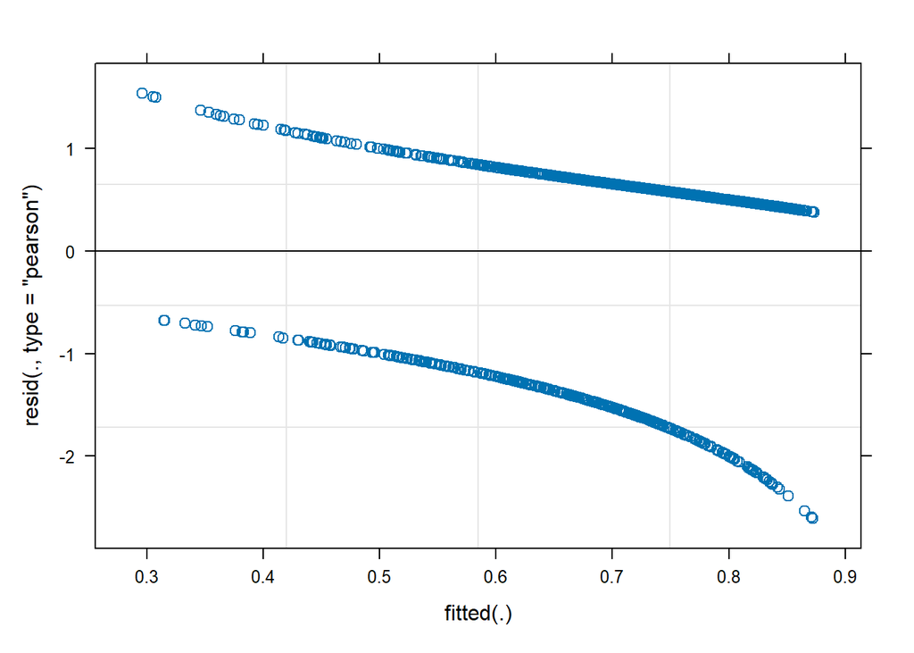

```r
rq1data$linfit <- predict(rq1mod1, rq1data)

rq1data$linprobs <- exp(rq1data$linfit)/(1+exp(rq1data$linfit))

plot(rq1mod1)
```

MODEL FIT: AIC = 1700.23, BIC = 1716.08 Pseudo-R² (fixed effects) = 0.05 Pseudo-R² (total) = 0.08 DF = 1453

Fit with maximum likelihood (Laplace Approximation)

```r
exp(sum1$coefficients[2])
```

```
## [1] 1.033623
```

```r
exp(sum1$coefficients[1])/(1+exp(sum1$coefficients[1]))
```

```
## [1] 0.149427
```

```r
x = 100

o = sum1$coefficients[1] + (sum1$coefficients[2]*x)


exp(o)/(1+exp(o))
```

```
## [1] 0.827487
```

According to the linear model, a person with a hypothetical 0% score on the exam would have a 14.94% probability of viewing their exam feedback. The model also showed a significant positive linear relationship. Each point increase of written score is a .03 logit increase or 1.03 times the probability of viewing feedback. A student with a score of 1% would be expected to have 15.37% probability. A student with the score of 50% would be expected have q 47.86% probability and a student with a score of 100% would be expected to have a 82.75% probability of viewing their feedback.

Time ICC = .03 - 3% of the variance is due to differences across time quite small suggesting that time varying effects are likely insignificant.

## Model 2

```r
rq1data <- rq1data %>% mutate(squared = (p_score^2)/100)

sqEq <- "viewed~p_score + squared + (1|time)"
rq1mod2 <- glmer(sqEq, rq1data, family = "binomial")

summ(rq1mod2)
```

```
## MODEL INFO:
## Observations: 1456
## Dependent Variable: viewed
## Type: Mixed effects generalized linear regression
## Error Distribution: binomial
## Link function: logit
##
## MODEL FIT:
## AIC = 1683.87, BIC = 1705.00
## Pseudo-R² (fixed effects) = 0.08
## Pseudo-R² (total) = 0.11
##
## FIXED EFFECTS:
## ------------------------------------------------
##                      Est.   S.E.   z val.      p
## ----------------- ------- ------ -------- ------
## (Intercept)          3.90   1.41     2.77   0.01
## p_score             -0.13   0.04    -3.30   0.00
## squared              0.11   0.03     4.18   0.00
## ------------------------------------------------
##
## RANDOM EFFECTS:
## ---------------------------------
##  Group    Parameter    Std. Dev.
## ------- ------------- -----------
##  time    (Intercept)     0.33
## ---------------------------------
##
## Grouping variables:
## -------------------------
##  Group   # groups   ICC
## ------- ---------- ------
##  time       4       0.03
## -------------------------
```

```r
sum2 <- summary(rq1mod2)
sum2
```

```
## Generalized linear mixed model fit by maximum likelihood (Laplace
##   Approximation) [glmerMod]
##  Family: binomial  ( logit )
## Formula: viewed ~ p_score + squared + (1 | time)
##    Data: rq1data
##
##       AIC       BIC    logLik -2*log(L)  df.resid
##    1683.9    1705.0    -837.9    1675.9      1452
##
## Scaled residuals:
##     Min      1Q  Median      3Q     Max
## -3.5055 -1.0345  0.4855  0.6788  1.0897
##
## Random effects:
##  Groups Name        Variance Std.Dev.
##  time   (Intercept) 0.1065   0.3263
## Number of obs: 1456, groups:  time, 4
##
## Fixed effects:
##             Estimate Std. Error z value Pr(>|z|)
## (Intercept)  3.90172    1.40797   2.771 0.005586 **
## p_score     -0.12906    0.03906  -3.304 0.000954 ***
## squared      0.11184    0.02678   4.176 2.96e-05 ***
## ---
## Signif. codes:  0 '***' 0.001 '**' 0.01 '*' 0.05 '.' 0.1 ' ' 1
##
## Correlation of Fixed Effects:
##         (Intr) p_scor
## p_score -0.983
## squared  0.960 -0.993
```

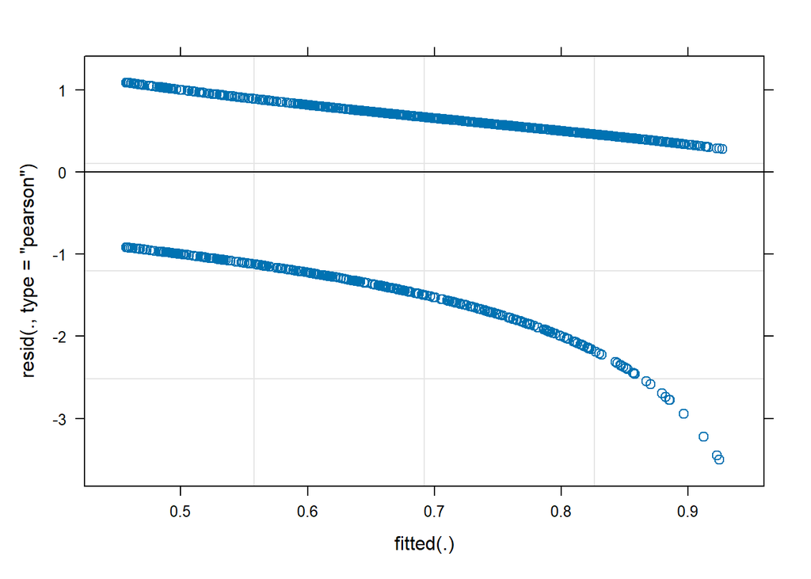

```r
rq1data$sqfit <- predict(rq1mod2, rq1data)

rq1data$sqprobs <- exp(rq1data$sqfit)/(1+exp(rq1data$sqfit))

plot(rq1mod2)
```

```r
anova(rq1mod1, rq1mod2)
```

|  | npar | AIC | BIC | logLik | -2*log(L) | Chisq | Df | Pr(>Chisq) |
| --- | --- | --- | --- | --- | --- | --- | --- | --- |
| rq1mod1 | 3 | 1700.228 | 1716.078 | -847.1138 | 1694.228 | NA | NA | NA |
| rq1mod2 | 4 | 1683.867 | 1705.001 | -837.9335 | 1675.867 | 18.36067 | 1 | 1.827929e-05 |

MODEL FIT: AIC = 1683.87, BIC = 1705.00 Pseudo-R² (fixed effects) = 0.08 Pseudo-R² (total) = 0.11 DF = 1452

maximum likelihood (Laplace Approximation) [glmerMod]

```r
exp(sum2$coefficients[2])
```

```
## [1] 0.8789226
```

```r
exp(sum2$coefficients[1])/(1+exp(sum2$coefficients[1]))
```

```
## [1] 0.9801932
```

```r
x = 100

o = sum2$coefficients[1] + (sum2$coefficients[2]*x) + (sum2$coefficients[3]*(x^2/100))


exp(o)/(1+exp(o))
```

```
## [1] 0.8984297
```

This means that, while accounting for time varying effects, a student with a hypothetical score of 1% would have a 97.76% probability of viewing their exam, but a student with a 50% score would have an expected probability of 56.09 % and a student with 100% on the exam would be expected to have a 89.84% probability of viewing thier feedback.

Fits significantly better difference in X-square 18.361 p < .001

## Model 3 — failed to converge

```r
rq1data <- rq1data %>% mutate(cubed = (p_score^3/ 1000))

cubeEq <- "viewed~p_score + squared + cubed + (1|time)"
rq1mod3 <- glmer(cubeEq, rq1data, family = "binomial")
#remove(rq1mod3)
summ(rq1mod3)
```

```
## MODEL INFO:
## Observations: 1456
## Dependent Variable: viewed
## Type: Mixed effects generalized linear regression
## Error Distribution: binomial
## Link function: logit
##
## MODEL FIT:
## AIC = 1683.80, BIC = 1710.22
## Pseudo-R² (fixed effects) = 0.08
## Pseudo-R² (total) = 0.11
##
## FIXED EFFECTS:
## ------------------------------------------------
##                      Est.   S.E.   z val.      p
## ----------------- ------- ------ -------- ------
## (Intercept)         -2.45   4.18    -0.59   0.56
## p_score              0.17   0.19     0.89   0.38
## squared             -0.33   0.28    -1.19   0.24
## cubed                0.02   0.01     1.59   0.11
## ------------------------------------------------
##
## RANDOM EFFECTS:
## ---------------------------------
##  Group    Parameter    Std. Dev.
## ------- ------------- -----------
##  time    (Intercept)     0.33
## ---------------------------------
##
## Grouping variables:
## -------------------------
##  Group   # groups   ICC
## ------- ---------- ------
##  time       4       0.03
## -------------------------
```

```r
summary(rq1mod3)
```

```
## Generalized linear mixed model fit by maximum likelihood (Laplace
##   Approximation) [glmerMod]
##  Family: binomial  ( logit )
## Formula: viewed ~ p_score + squared + cubed + (1 | time)
##    Data: rq1data
##
##       AIC       BIC    logLik -2*log(L)  df.resid
##    1683.8    1710.2    -836.9    1673.8      1451
##
## Scaled residuals:
##     Min      1Q  Median      3Q     Max
## -4.0075 -1.0435  0.4791  0.6903  1.0293
##
## Random effects:
##  Groups Name        Variance Std.Dev.
##  time   (Intercept) 0.1089   0.33
## Number of obs: 1456, groups:  time, 4
##
## Fixed effects:
##             Estimate Std. Error z value Pr(>|z|)
## (Intercept) -2.44847    4.18123  -0.586    0.558
## p_score      0.16823    0.18975   0.887    0.375
## squared     -0.33160    0.27962  -1.186    0.236
## cubed        0.02126    0.01339   1.587    0.112
##
## Correlation of Fixed Effects:
##         (Intr) p_scor squard
## p_score -0.990
## squared  0.970 -0.994
## cubed   -0.944  0.979 -0.996
## optimizer (Nelder_Mead) convergence code: 0 (OK)
## Model failed to converge with max|grad| = 0.0622707 (tol = 0.002, component 1)
## Model is nearly unidentifiable: very large eigenvalue
##  - Rescale variables?
## Model is nearly unidentifiable: large eigenvalue ratio
##  - Rescale variables?
```

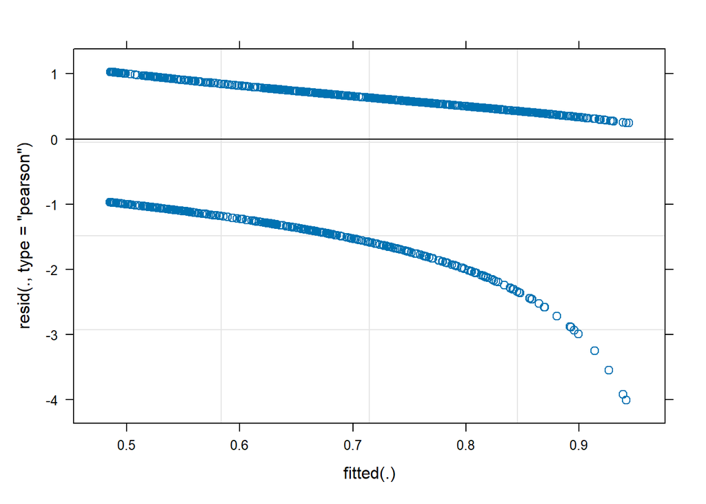

```r
rq1data$cubefit <- predict(rq1mod3, rq1data)

rq1data$cubeprobs <- exp(rq1data$cubefit)/(1+exp(rq1data$cubefit))

plot(rq1mod3)
```

```r
exp(-.01)
```

```
## [1] 0.9900498
```

```r
anova(rq1mod2, rq1mod3)
```

|  | npar | AIC | BIC | logLik | -2*log(L) | Chisq | Df | Pr(>Chisq) |
| --- | --- | --- | --- | --- | --- | --- | --- | --- |
| rq1mod2 | 4 | 1683.867 | 1705.001 | -837.9335 | 1675.867 | NA | NA | NA |
| rq1mod3 | 5 | 1683.801 | 1710.218 | -836.9005 | 1673.801 | 2.065894 | 1 | 0.1506265 |

AIC = 1683.80, BIC = 1710.22 Pseudo-R² (fixed effects) = 0.08 Pseudo-R² (total) = 0.11

## plot

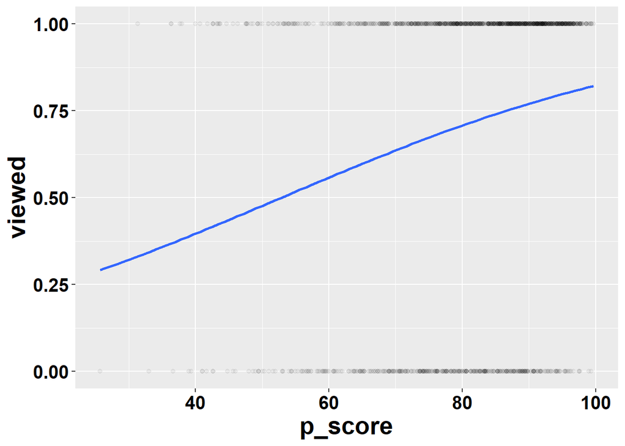

```r
colors <- c( "#FFFFFF", "#030303", "#A3A3A3", "#F5F5F5", "#191970", "#104E8B", "#00688B", "#00868B","#458B74", "#006400")

#colourPicker()

plot <-  ggplot(rq1data) +theme (axis.text.x = element_text(face = "bold", color = colors[2],
                             size =15),
  axis.text.y = element_text(face = "bold", color = colors[2],
                             size = 15),
  legend.text = element_text(color = colors[2], face = "bold", size = 18),
  legend.title = element_text(color = colors[2], face = "bold"),
  axis.title.x = element_text(color = colors[2],face = "bold",size = 20 ),
  axis.title.y = element_text(color = colors[2],face = "bold",size = 20 ))

rq1Linplot <- plot + geom_point(aes(x = p_score, y = viewed), alpha = .05) + geom_smooth(aes(x = p_score, y = linprobs), method = "glm",
    method.args = list(family = "binomial"),
    se = FALSE)

rq1Linplot
```

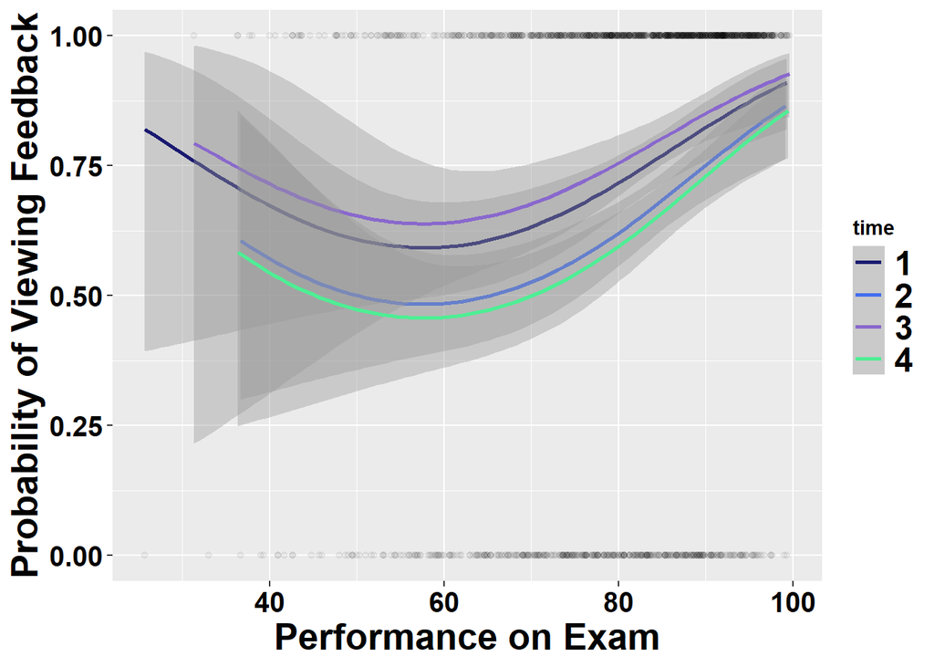

```r
rq1Sqplot <- plot + geom_point(aes(x = p_score, y = viewed), alpha = .05) + geom_smooth(aes(x = p_score, y = sqprobs, color = time), method = "glm", method.args = list(family = "binomial"),  formula = y~ x + poly(x,2), linewidth = 1) + scale_x_continuous(name = "Performance on Exam") + scale_y_continuous(name = "Probability of Viewing Feedback") + scale_color_manual(values = c("#191970" ,"#436EEE", "#8968CD" ,"#4EEE94"))
rq1Sqplot
```

```r
?geom_point
```

```
## starting httpd help server ... done
```

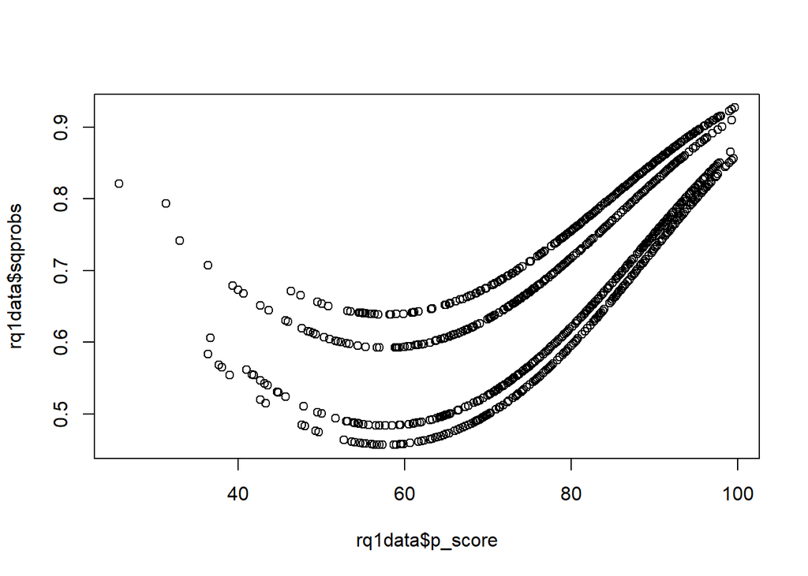

```r
ggsave(rq1Sqplot, file = "Rq1Plot.png")
plot(rq1data$p_score, rq1data$sqprobs)
```

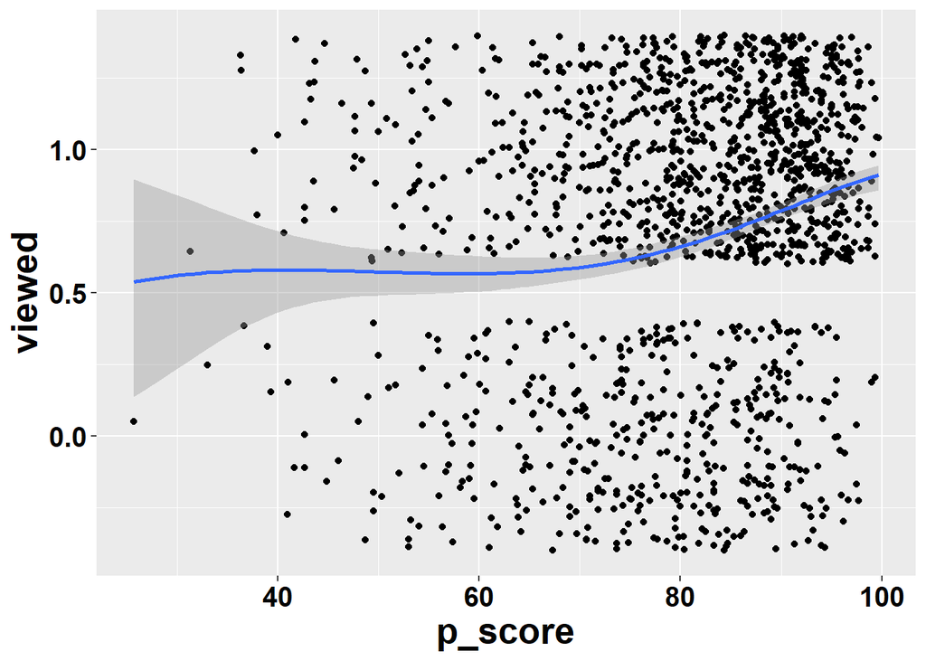

```r
rq1Cubeplot <- plot + geom_point(aes(x = p_score, y = viewed), position = "jitter", linewidth = 1) + geom_smooth(aes(x = p_score, y = cubeprobs), method = "glm", method.args = list(family = "binomial"),  formula = y~ x + poly(x, 2) + poly(x,3))
?geom_smooth
rq1Cubeplot
```

## Exploratory

```r
erq1 <- data %>% mutate(grade = case_when(p_score >= 90 ~ "A", p_score >= 80 ~ "B", p_score >= 70 ~ "C", p_score >= 60 ~ "D", p_score < 60 ~ "F"))

grade_viewing <- erq1 %>% group_by(grade) %>% summarise(
  proportion = mean(viewed, na.rm = T), sd = sd(viewed, na.rm = T)
)

grade_viewing
```

| grade | proportion | sd |
| --- | --- | --- |
| A | 0.8511749 | 0.3563815 |
| B | 0.7066381 | 0.4557911 |
| C | 0.6474164 | 0.4785022 |
| D | 0.5695364 | 0.4967888 |
| F | 0.5476190 | 0.4997142 |

```r
mod4 <- glm("viewed~grade", erq1, family = "binomial")

summ(mod4)
```

```
## MODEL INFO:
## Observations: 1456
## Dependent Variable: viewed
## Type: Generalized linear model
##   Family: binomial
##   Link function: logit
##
## MODEL FIT:
## χ²(4) = 76.21, p = 0.00
## Pseudo-R² (Cragg-Uhler) = 0.07
## Pseudo-R² (McFadden) = 0.04
## AIC = 1704.42, BIC = 1730.83
##
## Standard errors:MLE
## ------------------------------------------------
##                      Est.   S.E.   z val.      p
## ----------------- ------- ------ -------- ------
## (Intercept)          1.74   0.14    12.15   0.00
## gradeB              -0.86   0.18    -4.92   0.00
## gradeC              -1.14   0.18    -6.17   0.00
## gradeD              -1.46   0.22    -6.71   0.00
## gradeF              -1.55   0.23    -6.77   0.00
## ------------------------------------------------
```

# RQ 2 Analyis

### Visualize Feedback Viewing

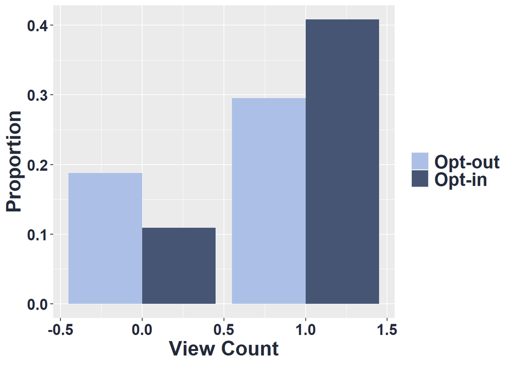

```r
colors <- c("black", "#ACBFE6", "#465573", "#232A3A" )


plot <- ggplot(data) +theme (axis.text.x = element_text(face = "bold", color = colors[4],
                             size =15),
  axis.text.y = element_text(face = "bold", color = colors[4],
                             size = 15),
  legend.text = element_text(color = colors[4], face = "bold", size = 18),
  legend.title = element_text(color = colors[4], face = "bold"),
  axis.title.x = element_text(color = colors[4],face = "bold",size = 20 ),
  axis.title.y = element_text(color = colors[4],face = "bold",size = 20 ))




view_optin <- plot + geom_bar(aes(x = viewed, y = after_stat(count/sum(count)), fill = opt_in), position = "dodge") + scale_fill_manual(values = c("#ACBFE6", "#465573"), name = " ", labels = c("Opt-out", "Opt-in")) + labs(x = "View Count", y = "Proportion")

view_optin
```

```r
ggsave(view_optin, file = "view_optin.png", height = 5, width = 11.5)
```

view = b0i * time1 + b1 * time2 + b2 * time3 + b4 * time4 + e

b0j = b0 + studenti

view = 1.81 + -.74 (if time2) + .58 (if time3) + -.76 (if time4) ### Model 1: Does Observation time predict Feedback Viewing?

```r
model1 <- glmer(viewed ~  time + (1|student_id),  data, family = binomial)

summ(model1)
```

```
## MODEL INFO:
## Observations: 1456
## Dependent Variable: viewed
## Type: Mixed effects generalized linear regression
## Error Distribution: binomial
## Link function: logit
##
## MODEL FIT:
## AIC = 1515.26, BIC = 1541.68
## Pseudo-R² (fixed effects) = 0.04
## Pseudo-R² (total) = 0.60
##
## FIXED EFFECTS:
## ------------------------------------------------
##                      Est.   S.E.   z val.      p
## ----------------- ------- ------ -------- ------
## (Intercept)          1.81   0.22     8.30   0.00
## time2               -0.74   0.21    -3.46   0.00
## time3                0.58   0.23     2.52   0.01
## time4               -0.76   0.21    -3.55   0.00
## ------------------------------------------------
##
## RANDOM EFFECTS:
## --------------------------------------
##    Group       Parameter    Std. Dev.
## ------------ ------------- -----------
##  student_id   (Intercept)     2.17
## --------------------------------------
##
## Grouping variables:
## ------------------------------
##    Group      # groups   ICC
## ------------ ---------- ------
##  student_id     370      0.59
## ------------------------------
```

```r
sum21 <- summary(model1)

sum21
```

```
## Generalized linear mixed model fit by maximum likelihood (Laplace
##   Approximation) [glmerMod]
##  Family: binomial  ( logit )
## Formula: viewed ~ time + (1 | student_id)
##    Data: data
##
##       AIC       BIC    logLik -2*log(L)  df.resid
##    1515.3    1541.7    -752.6    1505.3      1451
##
## Scaled residuals:
##     Min      1Q  Median      3Q     Max
## -2.8338 -0.4284  0.2199  0.3432  1.7525
##
## Random effects:
##  Groups     Name        Variance Std.Dev.
##  student_id (Intercept) 4.718    2.172
## Number of obs: 1456, groups:  student_id, 370
##
## Fixed effects:
##             Estimate Std. Error z value Pr(>|z|)
## (Intercept)   1.8103     0.2182   8.296  < 2e-16 ***
## time2        -0.7414     0.2140  -3.465 0.000530 ***
## time3         0.5820     0.2306   2.524 0.011611 *
## time4        -0.7605     0.2143  -3.548 0.000387 ***
## ---
## Signif. codes:  0 '***' 0.001 '**' 0.01 '*' 0.05 '.' 0.1 ' ' 1
##
## Correlation of Fixed Effects:
##       (Intr) time2  time3
## time2 -0.578
## time3 -0.435  0.471
## time4 -0.577  0.548  0.470
```

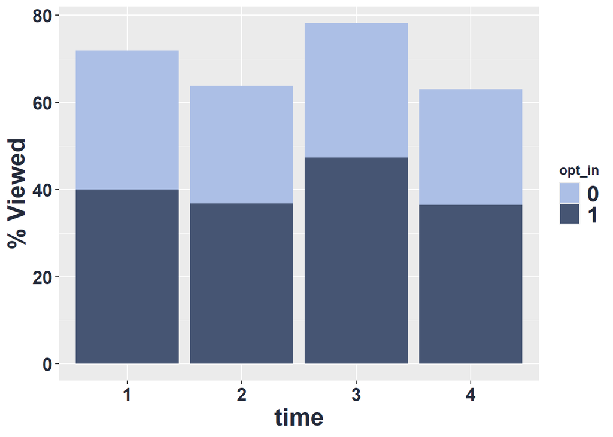

```r
view_time <- plot + geom_bar(aes(x = time, y = (viewed/370)*100, fill = opt_in), stat = "identity") + scale_y_continuous(name = "% Viewed") + scale_fill_manual(values = c(colors[2], colors[3]))


view_time
```

```r
exp(sum1$coefficients[2])
```

```
## [1] 1.033623
```

```r
exp(sum21$coefficients[1])/(1+exp(sum21$coefficients[1]))
```

```
## [1] 0.8594012
```

```r
o = sum21$coefficients[1] + (sum21$coefficients[4])


exp(o)/(1+exp(o))
```

```
## [1] 0.7407413
```

maximum likelihood (Laplace Approximation) [glmerMod]

Time 1 is between exam 1 & 2 Time 2 is Between 2 & 3 Time 3 is between 3 & 4 — intervention time period Time 4 is between 4 & 5 – post intervention lag 1

Pre-registered alpha of .01:

Student who opt-in are overall more likely to view their feedback. Not surprising since students are forced to look at feedback to do this intervention.

viewed = b0i*time1 + b1*optin + b2*time2 + b3*time3 + b4*time4 + b5*optin*time2 + b6*time3*optin + b7*time4*optin + e

b0i = b0 + studenti

### Model 2: Feedback viewing over time by intervention group

```r
eq2 <- viewed ~ opt_in + time + opt_in*time + (1|student_id)
model2 <- glmer(eq2, data = data,  family = binomial)
summ(model2)
```

```
## MODEL INFO:
## Observations: 1456
## Dependent Variable: viewed
## Type: Mixed effects generalized linear regression
## Error Distribution: binomial
## Link function: logit
##
## MODEL FIT:
## AIC = 1473.51, BIC = 1521.06
## Pseudo-R² (fixed effects) = 0.14
## Pseudo-R² (total) = 0.62
##
## FIXED EFFECTS:
## --------------------------------------------------
##                        Est.   S.E.   z val.      p
## ------------------- ------- ------ -------- ------
## (Intercept)            1.28   0.27     4.67   0.00
## opt_in1                0.90   0.39     2.33   0.02
## time2                 -0.81   0.30    -2.73   0.01
## time3                 -0.20   0.30    -0.66   0.51
## time4                 -0.84   0.30    -2.82   0.00
## opt_in1:time2          0.18   0.42     0.42   0.68
## opt_in1:time3          2.05   0.51     4.02   0.00
## opt_in1:time4          0.17   0.42     0.41   0.68
## --------------------------------------------------
##
## RANDOM EFFECTS:
## --------------------------------------
##    Group       Parameter    Std. Dev.
## ------------ ------------- -----------
##  student_id   (Intercept)     2.05
## --------------------------------------
##
## Grouping variables:
## ------------------------------
##    Group      # groups   ICC
## ------------ ---------- ------
##  student_id     370      0.56
## ------------------------------
```

```r
sum22 <- summary(model2)
sum22
```

```
## Generalized linear mixed model fit by maximum likelihood (Laplace
##   Approximation) [glmerMod]
##  Family: binomial  ( logit )
## Formula: viewed ~ opt_in + time + opt_in * time + (1 | student_id)
##    Data: data
##
##       AIC       BIC    logLik -2*log(L)  df.resid
##    1473.5    1521.1    -727.8    1455.5      1447
##
## Scaled residuals:
##     Min      1Q  Median      3Q     Max
## -5.2860 -0.4109  0.2450  0.3723  1.8024
##
## Random effects:
##  Groups     Name        Variance Std.Dev.
##  student_id (Intercept) 4.196    2.048
## Number of obs: 1456, groups:  student_id, 370
##
## Fixed effects:
##               Estimate Std. Error z value Pr(>|z|)
## (Intercept)     1.2826     0.2748   4.668 3.05e-06 ***
## opt_in1         0.9017     0.3874   2.327  0.01994 *
## time2          -0.8059     0.2956  -2.726  0.00641 **
## time3          -0.1966     0.2989  -0.658  0.51072
## time4          -0.8370     0.2967  -2.821  0.00479 **
## opt_in1:time2   0.1760     0.4216   0.417  0.67642
## opt_in1:time3   2.0546     0.5106   4.024 5.73e-05 ***
## opt_in1:time4   0.1744     0.4221   0.413  0.67956
## ---
## Signif. codes:  0 '***' 0.001 '**' 0.01 '*' 0.05 '.' 0.1 ' ' 1
##
## Correlation of Fixed Effects:
##             (Intr) opt_n1 time2  time3  time4  op_1:2 op_1:3
## opt_in1     -0.647
## time2       -0.587  0.385
## time3       -0.557  0.386  0.515
## time4       -0.585  0.384  0.532  0.514
## opt_in1:tm2  0.400 -0.585 -0.695 -0.359 -0.368
## opt_in1:tm3  0.354 -0.459 -0.315 -0.589 -0.315  0.440
## opt_in1:tm4  0.399 -0.585 -0.368 -0.359 -0.697  0.540  0.439
## optimizer (Nelder_Mead) convergence code: 0 (OK)
## Model failed to converge with max|grad| = 0.54991 (tol = 0.002, component 1)
```

```r
anova(model1, model2)
```

|  | npar | AIC | BIC | logLik | -2*log(L) | Chisq | Df | Pr(>Chisq) |
| --- | --- | --- | --- | --- | --- | --- | --- | --- |
| model1 | 5 | 1515.262 | 1541.679 | -752.6311 | 1505.262 | NA | NA | NA |
| model2 | 9 | 1473.506 | 1521.057 | -727.7532 | 1455.506 | 49.75582 | 4 | 4.060595e-10 |

```r
exp(sum22$coefficients[1])/(1+exp(sum22$coefficients[1]))
```

```
## [1] 0.7828988
```

```r
exp(sum22$coefficients[2])
```

```
## [1] 2.463824
```

```r
exp( sum22$coefficients[2] + sum22$coefficients[7] )
```

```
## [1] 19.22661
```

```r
o = sum22$coefficients[1] + sum22$coefficients[2] + sum22$coefficients[8]


exp(o)/(1+exp(o))
```

```
## [1] 0.9136246
```

AIC = 1473.51, BIC = 1521.06 Pseudo-R² (fixed effects) = 0.14 Pseudo-R² (total) = 0.62

The only time that feedback viewing behavior significantly differed by group is between Exam 3 & 4 when the students who did the intervention were required to look at and correct thier feedback.

# RQ 3: Performance

## Descriptives

```r
data$viewed <- as.factor(data$viewed)
opt_in_data <- data %>% filter(opt_in == 1)

opt_out_data <- data %>% filter(opt_in == 0)

performance_in_feedback <- opt_in_data %>% group_by(time) %>%  group_by(viewed, .add = T) %>% summarise(variable = "Subsequent Score", n = n(),
                                                    mean = mean(f_score, na.rm=T),
                                                    sd = sd(f_score, na.rm = T),
                                                    median = median(f_score, na.rm = T),
                                                    MAD = mad(f_score, na.rm = T),
                                                    Q1 = quantile(f_score, probs = .25, na.rm = T),
                                                    Q3 = quantile(f_score, probs = .75, na.rm = T),
                                                    IQR = IQR(f_score, na.rm = T),
                                                    min = min(f_score, na.rm = T),
                                                    max = max(f_score, na.rm = T))
performance_in_feedback
```

| time | viewed | variable | n | mean | sd | median | MAD | Q1 | Q3 | IQR | min | max |
| --- | --- | --- | --- | --- | --- | --- | --- | --- | --- | --- | --- | --- |
| 1 | 0 | Subsequent Score | 38 | 68.82353 | 16.94358 | 73.08824 | 11.55556 | 62.50000 | 79.04412 | 16.54412 | 29.117647 | 92.05882 |
| 1 | 1 | Subsequent Score | 148 | 74.21502 | 16.00910 | 77.20588 | 15.69812 | 66.39706 | 86.39706 | 20.00000 | 21.764706 | 98.52941 |
| 2 | 0 | Subsequent Score | 54 | 72.04304 | 16.80245 | 75.93750 | 13.43606 | 66.25000 | 84.68750 | 18.43750 | 26.562500 | 94.06250 |
| 2 | 1 | Subsequent Score | 136 | 80.40112 | 12.37494 | 83.75000 | 11.58281 | 73.75000 | 89.68750 | 15.93750 | 35.312500 | 98.75000 |
| 3 | 0 | Subsequent Score | 12 | 72.08333 | 20.44582 | 76.02941 | 20.49476 | 62.50000 | 81.39706 | 18.89706 | 31.176471 | 100.00000 |
| 3 | 1 | Subsequent Score | 175 | 81.16303 | 16.26162 | 85.88235 | 10.90147 | 75.29412 | 92.79412 | 17.50000 | 2.352941 | 99.11765 |
| 4 | 0 | Subsequent Score | 55 | 75.29186 | 14.06651 | 75.62500 | 14.82600 | 65.62500 | 85.31250 | 19.68750 | 45.937500 | 97.50000 |
| 4 | 1 | Subsequent Score | 135 | 83.81250 | 12.59883 | 86.25000 | 11.11950 | 78.43750 | 92.50000 | 14.06250 | 20.937500 | 100.00000 |

```r
performance_out_feedback <- opt_out_data %>% group_by(time) %>%  group_by(viewed, .add = T) %>% summarise(variable = "Subsequent Score", n = n(),
                                                    mean = mean(f_score, na.rm=T),
                                                    sd = sd(f_score, na.rm = T),
                                                    median = median(f_score, na.rm = T),
                                                    MAD = mad(f_score, na.rm = T),
                                                    Q1 = quantile(f_score, probs = .25, na.rm = T),
                                                    Q3 = quantile(f_score, probs = .75, na.rm = T),
                                                    IQR = IQR(f_score, na.rm = T),
                                                    min = min(f_score, na.rm = T),
                                                    max = max(f_score, na.rm = T))
performance_out_feedback
```

| time | viewed | variable | n | mean | sd | median | MAD | Q1 | Q3 | IQR | min | max |
| --- | --- | --- | --- | --- | --- | --- | --- | --- | --- | --- | --- | --- |
| 1 | 0 | Subsequent Score | 58 | 65.67595 | 17.06534 | 68.23529 | 19.62265 | 52.05882 | 78.82353 | 26.76471 | 27.05882 | 96.76471 |
| 1 | 1 | Subsequent Score | 118 | 77.69523 | 13.88274 | 82.05882 | 11.77359 | 68.67647 | 88.82353 | 20.14706 | 30.29412 | 95.88235 |
| 2 | 0 | Subsequent Score | 77 | 72.37196 | 13.44636 | 73.75000 | 15.75262 | 61.48438 | 82.96875 | 21.48438 | 40.31250 | 95.93750 |
| 2 | 1 | Subsequent Score | 100 | 79.64062 | 14.65273 | 83.28125 | 15.05766 | 71.25000 | 91.56250 | 20.31250 | 27.50000 | 99.37500 |
| 3 | 0 | Subsequent Score | 61 | 70.72806 | 14.34263 | 70.88235 | 16.57024 | 61.47059 | 82.05882 | 20.58824 | 37.64706 | 97.64706 |
| 3 | 1 | Subsequent Score | 114 | 79.96791 | 15.62631 | 84.70588 | 13.95388 | 68.38235 | 92.35294 | 23.97059 | 30.58824 | 100.00000 |
| 4 | 0 | Subsequent Score | 77 | 73.30833 | 12.92623 | 75.62500 | 13.89937 | 62.65625 | 84.37500 | 21.71875 | 36.87500 | 98.12500 |
| 4 | 1 | Subsequent Score | 98 | 80.72862 | 13.95258 | 83.12500 | 12.04612 | 75.00000 | 91.71875 | 16.71875 | 37.50000 | 100.00000 |

```r
write.csv(performance_in_feedback, file = "Opt-in Performance over time by feedback viewing.csv")

write.csv(performance_out_feedback, file = "Opt-out Performance over time by feedback viewing.csv")


performance_feedback <- data %>% group_by(time)  %>% summarise(variable = "Subsequent Score", n = n(),
                                                    mean = mean(f_score, na.rm=T),
                                                    sd = sd(f_score, na.rm = T),
                                                    median = median(f_score, na.rm = T),
                                                    MAD = mad(f_score, na.rm = T),
                                                    Q1 = quantile(f_score, probs = .25, na.rm = T),
                                                    Q3 = quantile(f_score, probs = .75, na.rm = T),
                                                    IQR = IQR(f_score, na.rm = T),
                                                    min = min(f_score, na.rm = T),
                                                    max = max(f_score, na.rm = T))

performance_feedback
```

| time | variable | n | mean | sd | median | MAD | Q1 | Q3 | IQR | min | max |
| --- | --- | --- | --- | --- | --- | --- | --- | --- | --- | --- | --- |
| 1 | Subsequent Score | 362 | 73.41308 | 16.13529 | 76.47059 | 15.69812 | 63.97059 | 86.02941 | 22.05882 | 21.764706 | 98.52941 |
| 2 | Subsequent Score | 367 | 77.34506 | 14.39564 | 80.62500 | 14.36269 | 69.37500 | 88.12500 | 18.75000 | 26.562500 | 99.37500 |
| 3 | Subsequent Score | 362 | 78.71344 | 16.33078 | 83.52941 | 13.95388 | 69.11765 | 91.17647 | 22.05882 | 2.352941 | 100.00000 |
| 4 | Subsequent Score | 365 | 79.53212 | 13.87119 | 82.18750 | 13.43606 | 71.25000 | 90.00000 | 18.75000 | 20.937500 | 100.00000 |

```r
write.csv(performance_feedback, file = "overall performance over time by feedback viewing.csv")

data %>% group_by()
```

[output not shown]

[output cut: 1446 more lines]

## Model 1: Does feedback viewing on Exam X predict performance on Exam X+1?

```r
eq1 <- f_score ~ viewed + (1|student_id) + (1|time)

m1 <- lmer(eq1, data)

summary(m1)
```

```
## Linear mixed model fit by REML. t-tests use Satterthwaite's method [
## lmerModLmerTest]
## Formula: eq1
##    Data: data
##
## REML criterion at convergence: 11347.9
##
## Scaled residuals:
##     Min      1Q  Median      3Q     Max
## -6.5460 -0.4710  0.1209  0.5917  3.1713
##
## Random effects:
##  Groups     Name        Variance Std.Dev.
##  student_id (Intercept) 116.589  10.798
##  time       (Intercept)   8.089   2.844
##  Residual               103.508  10.174
## Number of obs: 1434, groups:  student_id, 370; time, 4
##
## Fixed effects:
##              Estimate Std. Error        df t value Pr(>|t|)
## (Intercept)   74.1831     1.6536    5.1044  44.862 7.93e-08 ***
## viewed1        4.3048     0.8075 1400.3306   5.331 1.14e-07 ***
## ---
## Signif. codes:  0 '***' 0.001 '**' 0.01 '*' 0.05 '.' 0.1 ' ' 1
##
## Correlation of Fixed Effects:
##         (Intr)
## viewed1 -0.344
```

REML. t-tests use Satterthwaite’s method [lmerModLmerTest]

## Is feedback viewing sufficient to serve as the mechanism that explains the changes in performance trajectories for the two groups before and after the intervention?

## Model 2

### Performance over time

```r
eq2 <- f_score ~ time + (1|student_id)

m2 <- lmer(eq2, data)

summ(m2)
```

```
## MODEL INFO:
## Observations: 1434
## Dependent Variable: f_score
## Type: Mixed effects linear regression
##
## MODEL FIT:
## AIC = 11372.53, BIC = 11404.14
## Pseudo-R² (fixed effects) = 0.03
## Pseudo-R² (total) = 0.56
##
## FIXED EFFECTS:
## ----------------------------------------------------------
##                      Est.   S.E.   t val.      d.f.      p
## ----------------- ------- ------ -------- --------- ------
## (Intercept)         73.25   0.80    91.82    776.44   0.00
## time2                4.00   0.76     5.26   1067.19   0.00
## time3                5.50   0.76     7.20   1069.78   0.00
## time4                6.36   0.76     8.34   1068.61   0.00
## ----------------------------------------------------------
##
## p values calculated using Satterthwaite d.f.
##
## RANDOM EFFECTS:
## --------------------------------------
##    Group       Parameter    Std. Dev.
## ------------ ------------- -----------
##  student_id   (Intercept)     11.32
##   Residual                    10.17
## --------------------------------------
##
## Grouping variables:
## ------------------------------
##    Group      # groups   ICC
## ------------ ---------- ------
##  student_id     370      0.55
## ------------------------------
```

Overall, students perform better over time, p < .01.

### Performance over time by feedback viewing

```r
eq3 <- f_score ~ time + viewed + viewed*time + (1|student_id)

m3 <- lmer(eq3, data)

summ(m3)
```

```
## MODEL INFO:
## Observations: 1434
## Dependent Variable: f_score
## Type: Mixed effects linear regression
##
## MODEL FIT:
## AIC = 11342.12, BIC = 11394.80
## Pseudo-R² (fixed effects) = 0.04
## Pseudo-R² (total) = 0.55
##
## FIXED EFFECTS:
## ------------------------------------------------------------
##                        Est.   S.E.   t val.      d.f.      p
## ------------------- ------- ------ -------- --------- ------
## (Intercept)           69.79   1.29    54.16   1418.59   0.00
## time2                  5.22   1.45     3.59   1102.99   0.00
## time3                  4.72   1.69     2.80   1119.12   0.01
## time4                  7.16   1.46     4.91   1111.59   0.00
## viewed1                4.73   1.40     3.39   1232.36   0.00
## time2:viewed1         -1.26   1.77    -0.71   1118.86   0.48
## time3:viewed1          0.60   1.95     0.31   1132.95   0.76
## time4:viewed1         -0.59   1.79    -0.33   1131.60   0.74
## ------------------------------------------------------------
##
## p values calculated using Satterthwaite d.f.
##
## RANDOM EFFECTS:
## --------------------------------------
##    Group       Parameter    Std. Dev.
## ------------ ------------- -----------
##  student_id   (Intercept)     10.80
##   Residual                    10.18
## --------------------------------------
##
## Grouping variables:
## ------------------------------
##    Group      # groups   ICC
## ------------ ---------- ------
##  student_id     370      0.53
## ------------------------------
```

### Performance over time by intervention and feedback viewing

```r
eq4 <- f_score ~ time + viewed + opt_in  + time*opt_in + time*viewed + opt_in*viewed + time*viewed*opt_in + (1|student_id)

m4 <- lmer(eq4, data)

sum32 <- summary(m4)
```

Linear mixed model fit by REML. t-tests use Satterthwaite’s method [ lmerModLmerTest]

## Estimated Performance

```r
time2 = 0
time3 = 0
time4 = 1
optin = 1
views = 1




sum32$coefficients[1] + sum32$coefficients[2]*time2 + sum32$coefficients[3]*time3 + sum32$coefficients[4]*time4 + sum32$coefficients[5]*views + sum32$coefficients[6]*optin + sum32$coefficients[7]*time2*optin + sum32$coefficients[8]*time3*optin + sum32$coefficients[9]*time4*optin + sum32$coefficients[10]*time2*views + sum32$coefficients[11]*time3*views + sum32$coefficients[12]*time4*views + sum32$coefficients[13]*views*optin +  sum32$coefficients[14]*time2*views*optin + sum32$coefficients[15]*time3*views*optin + sum32$coefficients[16]*time4*views*optin
```

```
## [1] 82.60127
```

# RQ4